# Experiment 2 - Analysis

Bodo Winter

7/3/2019

## Preliminaries:

Load packages:

```r
library(tidyverse)
library(brms)
```

Load in data:

```r
header <- readLines('../data/E2_handshape.csv', n = 1)
E2 <- read_csv('../data/E2_handshape.csv', skip = 2,
               col_names = FALSE)
colnames(E2) <- unlist(str_split(header, ','))
```

Rename relevant columns:

```r
E2 <- rename(E2,
             Control = MathQuestion,
             Age = age,
             Gender = gender,
             Handedness = handedness,
             NativeLanguage = language,
             Condition = `DO-BR-FL_10`,
             Comments = OpenEnded,
             Notice = GestureNotice,
             ViewN = VideoNTimes,
             ViewYes = VideoCompletion,
             IP = V6,
             StartTime = V8,
             FinishTime = V9)
```

Get all_responses:

```r
# Initialize empty column for responses:

E2$Response <- NA

# The relevant columns all have '_resp':

these_cols <- str_detect(colnames(E2), 'E2_')

# The relevant columns all have '_resp':

for (i in 1:nrow(E2)) {
  this <- unlist(E2[i, these_cols])
  names(this) <- c()
  if (!all(is.na(this))) {
    E2[i, ]$Response <- this[!is.na(this)]
  }
  }
```

There’s some issue with the file, let’s get rid of the respective columns:

Select subset of dataframe with relevant columns:

```r
E2 <- select(E2,
             ViewYes:NativeLanguage, IP, Notice, Condition, StartTime, FinishTime, Response)
```

Exclude those partials that did not respond and report loss. For proper reporting (since there will be several rounds of exclusion), it makes sense to create a tibble:

```r
# Original tibble:

excl_tib <- tibble(N = nrow(E2), Type = 'Original')

# Those that didn't respond:

E2 <- filter(E2, !is.na(Response))

# New tibble to keep track of exclusions:

new_tib <- tibble(N = nrow(E2), Type = 'after partials')
excl_tib <- bind_rows(excl_tib, new_tib)
```

Exclude those that are duplicated responses (from the same IP):

```r
# Those that didn't respond:

these_IPs <- filter(E2, duplicated(IP)) %>% pull(IP)
E2 <- filter(E2, !(IP %in% these_IPs))

# New tibble to keep track of exclusions:

new_tib <- tibble(N = nrow(E2), Type = 'after duplicates')
excl_tib <- bind_rows(excl_tib, new_tib)
```

Get rid of non-native speakers:

```r
# Vector of things to exclude:

excludes <- c('Russian, English', 'Nepali', 'Telugu')

# Exclude:

E2 <- filter(E2, !(NativeLanguage %in% excludes))

# New tibble to keep track of exclusions:

new_tib <- tibble(N = nrow(E2), Type = 'after non-natives')
excl_tib <- bind_rows(excl_tib, new_tib)
```

Get rid of people who couldn’t view the videos:

```r
# Exclude:

E2 <- filter(E2, ViewYes == 'Yes')

# Get rid of those that report to have had a viewing problem:

excludes <- c("Video was lagging",
              "it buffered for a few seconds while viewing then continued.. that is why I had to view twice",
              "The video buffered a couple of times so I rewatched after it had completely loaded",
              "no had a little buffer but alright",
              "It was a bit glitchy.",
              "it took a long time to load and was a little choppy",
              "Yes, it didn't play correctly the first time.",
              "The picture took two plays to load.")

# Exclude these:

exclude_ids <- which(E2$VideoIssues %in% excludes)
E2 <- E2[-exclude_ids, ]

excludes <- c("Twice because it loaded slowly.",
              "2 days")
exclude_ids <- which(E2$ViewN %in% excludes)
E2 <- E2[-exclude_ids, ]

# New tibble to keep track of exclusions:

new_tib <- tibble(N = nrow(E2), Type = 'after viewing problems')
excl_tib <- bind_rows(excl_tib, new_tib)
```

Process viewing times:

```r
# Make it into lowercase for easier processing:

E2 <- mutate(E2, ViewN = str_to_lower(ViewN))

# Create a table that matches responses to counts:

ViewN <- c('1', 'once', 'one', "1.5", "once.", "1 time",
           '2', 'two', 'twice', '2 times',
           'three', '3', '3 because i had a hard time understanding what he was saying because of his accent.', "3 times",
           "4", "5")
ViewCount = c(1, 1, 1, 1, 1, 1,
              2, 2, 2, 2,
              3, 3, 3, 3,
              4, 5)
key <- tibble(ViewN, ViewCount)

# Merge these counts into the data frame:

E2 <- left_join(E2, key)
```

Assess whether the viewing times depend on condition:

```r
E2 %>% group_by(Condition) %>%
  summarize(sum = sum(ViewCount))
```

```
## # A tibble: 8 x 2
##   Condition          sum
##   <chr>            <dbl>
## 1 E2_SH_FLAT_BACK     57
## 2 E2_SH_FLAT_FORW     58
## 3 E2_SH_PUSH_BACK     54
## 4 E2_SH_PUSH_FORW     59
## 5 E2_TH_FLAT_BACK     52
## 6 E2_TH_FLAT_FORW     NA
## 7 E2_TH_PUSH_FORW     NA
## 8 E2_TWO_PUSH_BACK    NA
```

Not massive differences…

Create the Monday/Friday column:

```r
E2 <- mutate(E2, Response = str_to_lower(Response))

E2$RespClean <- NA
E2[str_detect(E2$Response, 'monday'), ]$RespClean <- 'monday'
E2[str_detect(E2$Response, 'friday'), ]$RespClean <- 'friday'

# Exclude those that responded neither monday nor friday:

E2 <- filter(E2, !is.na(RespClean))

# New tibble to keep track of exclusions:

new_tib <- tibble(N = nrow(E2), Type = 'after wrong-day responders')
excl_tib <- bind_rows(excl_tib, new_tib)
```

Code for multiple views versus single views:

```r
# If you wanted to take only those that had only one view:

# E2 <- filter(E2, ViewCount == 1)

# Multiple viewers as a separate variable:

E2 <- mutate(E2,
             MultipleView = ifelse(ViewCount == 1, 'single', 'multiple'))

# New tibble to keep track of exclusions (only necessary if excluded):

# new_tib <- tibble(N = nrow(E2), Type = 'after multiple viewers')
# excl_tib <- bind_rows(excl_tib, new_tib)
```

Code condition column:

```r
conditions <- str_split(E2$Condition, pattern = '_', simplify = TRUE)

E2$HandNumber <- conditions[, 2]
E2$HandShape <- conditions[, 3]
E2$Direction <- conditions[, 4]
```

Get rid of the original response column:

```r
E2 <- mutate(E2,
             Response = RespClean) %>%
  select(-RespClean)
```

For plotting make it so that the Response factor is “monday”, then “friday” (easier: from left to right).

```r
E2 <- mutate(E2,
             Response = str_to_title(Response),
             Response = factor(Response, levels = c('Monday', 'Friday')))
```

Change the labels in the Gesture and Language columns to make them better for plotting, and order factors for plotting:

```r
E2 <- mutate(E2,
             HandShape = ifelse(HandShape == 'FLAT', 'flat', 'push'),
             HandShape = factor(HandShape),
             Direction = ifelse(Direction == 'FORW', 'forward', 'backward'),
             Direction = factor(Direction,
                                levels = c('backward', 'forward')),
             HandNumber = ifelse(HandNumber == 'SH', 'single-handed', 'two-handed'),
             HandNumber = factor(HandNumber))
```

Overview of exclusions:

```r
excl_tib$Exclusions <- c(0, abs(diff(excl_tib$N)))
excl_tib$Prop <- NA
for (i in 2:nrow(excl_tib)) {
  excl_tib[i, ]$Prop <- excl_tib[i, ]$N / excl_tib[i - 1, ]$N
}
excl_tib <- mutate(excl_tib, Prop = 1 - Prop)
excl_tib
```

```
## # A tibble: 6 x 4
##       N Type                       Exclusions     Prop
##   <int> <chr>                           <dbl>    <dbl>
## 1   344 Original                            0 NA
## 2   296 after partials                     48  0.140
## 3   294 after duplicates                    2  0.00676
## 4   291 after non-natives                   3  0.0102
## 5   276 after viewing problems             15  0.0515
## 6   199 after wrong-day responders         77  0.279
```

And the overall exclusion:

```r
excl_tib[1, ]$N - excl_tib[nrow(excl_tib), ]$N
```

```
## [1] 145
```

```r
(excl_tib[1, ]$N - excl_tib[nrow(excl_tib), ]$N) / excl_tib[1, ]$N
```

```
## [1] 0.4215116
```

## Descriptive stats and visualizations:

First, how many were aware of the gestures?

```r
E2 %>% count(Notice, sort = TRUE)
```

```
## # A tibble: 5 x 2
##   Notice                 n
##   <chr>              <int>
## 1 Definitely yes       157
## 2 Probably yes          34
## 3 Probably not           4
## 4 Definitely not         2
## 5 Might or might not     2
```

Lots of them.

Tabulations of the main result:

```r
E2 %>% count(Response)
```

```
## # A tibble: 2 x 2
##   Response     n
##   <fct>    <int>
## 1 Monday      87
## 2 Friday     112
```

```r
E2 %>% count(Direction, Response)
```

```
## # A tibble: 4 x 3
##   Direction Response     n
##   <fct>     <fct>    <int>
## 1 backward  Monday      63
## 2 backward  Friday      34
## 3 forward   Monday      24
## 4 forward   Friday      78
```

More Monday responses when the language is backwards.

```r
E2 %>% count(HandNumber, Direction, Response)
```

```
## # A tibble: 8 x 4
##   HandNumber    Direction Response     n
##   <fct>         <fct>     <fct>    <int>
## 1 single-handed backward  Monday      28
## 2 single-handed backward  Friday      19
## 3 single-handed forward   Monday      15
## 4 single-handed forward   Friday      36
## 5 two-handed    backward  Monday      35
## 6 two-handed    backward  Friday      15
## 7 two-handed    forward   Monday       9
## 8 two-handed    forward   Friday      42
```

Handshape:

```r
E2 %>% count(HandShape, Direction, Response)
```

```
## # A tibble: 8 x 4
##   HandShape Direction Response     n
##   <fct>     <fct>     <fct>    <int>
## 1 flat      backward  Monday      37
## 2 flat      backward  Friday      14
## 3 flat      forward   Monday      17
## 4 flat      forward   Friday      39
## 5 push      backward  Monday      26
## 6 push      backward  Friday      20
## 7 push      forward   Monday       7
## 8 push      forward   Friday      39
```

Looks to be some stuff.

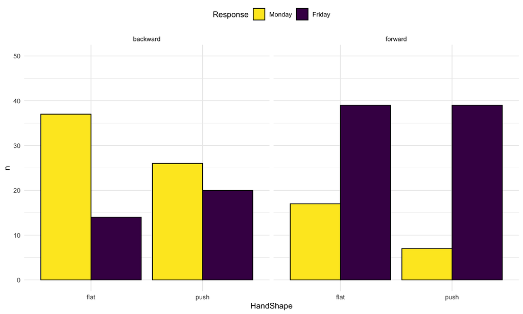

```r
E2 %>%
  count(Direction, HandShape, Response) %>%
  ggplot(aes(x = HandShape, y = n, fill = Response)) +
  geom_bar(stat = 'identity', col = 'black',
           position = 'dodge') +
  scale_fill_viridis_d(option = 'D', direction = -1) +
  theme_minimal() +
  ylim(0, 50) +
  theme(legend.position = 'top') +
  facet_wrap(~Direction)
```

## Publication ready stacked bar plot:

Stacked bar plot with percentages:

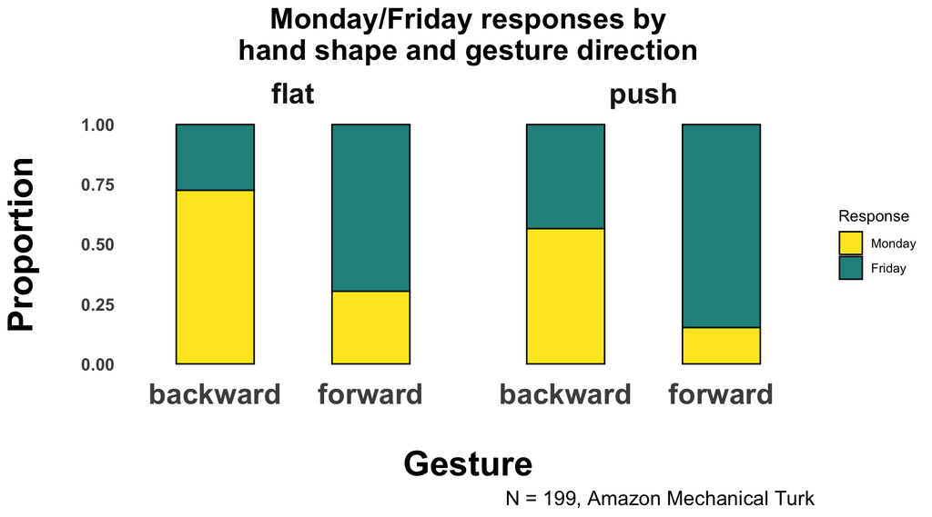

```r
E2 %>%
  count(HandShape, Direction, Response) %>%
  spread(Response, n) %>%
  mutate(Sum = Monday + Friday,
         Monday = Monday / Sum,
         Friday = Friday / Sum) %>%
  select(-Sum) %>%
  gather(key = 'Response', value = 'n',
         -(HandShape:Direction)) %>%
  mutate(Response = factor(Response,
                           levels = c('Monday', 'Friday'))) %>%
  rename(Proportion = n) %>%
  ggplot(aes(x = Direction, y = Proportion, fill = Response)) +
  geom_bar(stat = 'identity', col = 'black',
           position = position_stack(reverse = TRUE),
           width = 0.5) +
  scale_fill_manual(values = c('#FDE725FF', '#21908CFF')) +
  theme_minimal() +
  theme(legend.position = 'right') +
  facet_wrap(~HandShape) +
  labs(title = 'Monday/Friday responses by\nhand shape and gesture direction',
       caption = str_c('N = ', nrow(E2), ', Amazon Mechanical Turk')) +
  ylab('Proportion\n') +
  xlab('\nGesture') +
  theme(plot.title = element_text(face = 'bold', size = 20, hjust = 0.5),
        axis.title = element_text(face = 'bold', size = 24),
        axis.text.x = element_text(face = 'bold', size = 20),
        axis.text.y = element_text(face = 'bold', size = 12),
        strip.text.x = element_text(face = 'bold', size = 20),
        plot.caption = element_text(size = 14),
        panel.grid.minor = element_blank(),
        panel.grid.major = element_blank())
```

```r
ggsave('../figures/experiment2_hand_shape.png', width = 9, height = 6)
```

Same for two-handed versus one-handed:

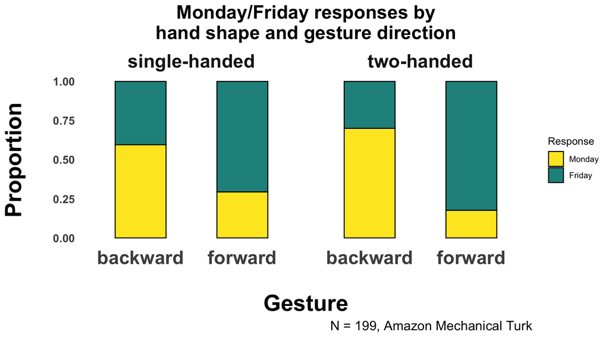

```r
E2 %>%
  count(HandNumber, Direction, Response) %>%
  spread(Response, n) %>%
  mutate(Sum = Monday + Friday,
         Monday = Monday / Sum,
         Friday = Friday / Sum) %>%
  select(-Sum) %>%
  gather(key = 'Response', value = 'n',
         -(HandNumber:Direction)) %>%
  mutate(Response = factor(Response,
                           levels = c('Monday', 'Friday'))) %>%
  rename(Proportion = n) %>%
  ggplot(aes(x = Direction, y = Proportion, fill = Response)) +
  geom_bar(stat = 'identity', col = 'black',
           position = position_stack(reverse = TRUE),
           width = 0.5) +
  scale_fill_manual(values = c('#FDE725FF', '#21908CFF')) +
  theme_minimal() +
  theme(legend.position = 'right') +
  facet_wrap(~HandNumber) +
  labs(title = 'Monday/Friday responses by\nhand shape and gesture direction',
       caption = str_c('N = ', nrow(E2), ', Amazon Mechanical Turk')) +
  ylab('Proportion\n') +
  xlab('\nGesture') +
  theme(plot.title = element_text(face = 'bold', size = 20, hjust = 0.5),
        axis.title = element_text(face = 'bold', size = 24),
        axis.text.x = element_text(face = 'bold', size = 20),
        axis.text.y = element_text(face = 'bold', size = 12),
        strip.text.x = element_text(face = 'bold', size = 20),
        plot.caption = element_text(size = 14),
        panel.grid.minor = element_blank(),
        panel.grid.major = element_blank())
```

```r
ggsave('../figures/experiment2_hand_number.png', width = 9, height = 6)
```

## Is there any indication of the direction effect being modulated by AQ/social skills?

Convert the scales for AQ:

```r
E2 <- mutate(E2,
       AQ2_face = ifelse(AQ2_face == 'strongly disagree', '1', AQ2_face),
       AQ2_face = ifelse(AQ2_face == 'slightly disagree', '2', AQ2_face),
       AQ2_face = ifelse(AQ2_face == 'slightly agree', '3', AQ2_face),
       AQ2_face = ifelse(AQ2_face == 'strongly agree', '4', AQ2_face),
       AQ2_face = as.numeric(AQ2_face),
       AQ1_face = ifelse(AQ1_face == 'strongly disagree', '1', AQ1_face),
       AQ1_face = ifelse(AQ1_face == 'slightly disagree', '2', AQ1_face),
       AQ1_face = ifelse(AQ1_face == 'slightly agree', '3', AQ1_face),
       AQ1_face = ifelse(AQ1_face == 'strongly agree', '4', AQ1_face),
       AQ1_face = as.numeric(AQ1_face))
```

Convert the scales for likeability:

```r
E2 <- mutate(E2,
       Likeability = ifelse(Likeability == 'strongly disagree', '1', Likeability),
       Likeability = ifelse(Likeability == 'slightly disagree', '2', Likeability),
       Likeability = ifelse(Likeability == 'slightly agree', '3', Likeability),
       Likeability = ifelse(Likeability == 'strongly agree', '4', Likeability),
       Likeability = as.numeric(Likeability),
       Warm = ifelse(Warm == 'strongly disagree', '1', Warm),
       Warm = ifelse(Warm == 'slightly disagree', '2', Warm),
       Warm = ifelse(Warm == 'slightly agree', '3', Warm),
       Warm = ifelse(Warm == 'strongly agree', '4', Warm),
       Warm = as.numeric(Warm),
       Friendly = ifelse(Friendly == 'strongly disagree', '1', Friendly),
       Friendly = ifelse(Friendly == 'slightly disagree', '2', Friendly),
       Friendly = ifelse(Friendly == 'slightly agree', '3', Friendly),
       Friendly = ifelse(Friendly == 'strongly agree', '4', Friendly),
       Friendly = as.numeric(Friendly),
       Approachability = ifelse(Approachability == 'strongly disagree', '1', Approachability),
       Approachability = ifelse(Approachability == 'slightly disagree', '2', Approachability),
       Approachability = ifelse(Approachability == 'slightly agree', '3', Approachability),
       Approachability = ifelse(Approachability == 'strongly agree', '4', Approachability),
       Approachability = as.numeric(Approachability))
```

Create sum scores:

```r
E2 <- mutate(E2,
             LikeScale = Friendly + Warm + Approachability + Likeability,
             AQ = AQ1_face + AQ2_face,
             LikeScale_c = LikeScale - mean(LikeScale),
             AQ_c = AQ - mean(AQ))
```

First, are these two measures correlated?

```r
with(E2, cor.test(LikeScale, AQ))
```

```
##
##  Pearson's product-moment correlation
##
## data:  LikeScale and AQ
## t = 2.5349, df = 196, p-value = 0.01203
## alternative hypothesis: true correlation is not equal to 0
## 95 percent confidence interval:
##  0.03971321 0.30991012
## sample estimates:
##       cor
## 0.1781681
```

Weakly correlated.

Next, how do they correspond to the responses. For this, it’ll be easiest to categorize people into high and low AQ / LikeScale based on median split … (this is just for visualization purposes).

```r
# Median split for AQ:

E2$AQ_cat <- NA
E2[E2$AQ < 5 & !is.na(E2$AQ), ]$AQ_cat <- 'low'
E2[E2$AQ > 5 & !is.na(E2$AQ), ]$AQ_cat <- 'high'

# Median split for Likeability:

E2$Like_cat <- NA
E2[E2$LikeScale > 13 & !is.na(E2$LikeScale), ]$Like_cat <- 'high'
E2[E2$LikeScale < 13 & !is.na(E2$LikeScale), ]$Like_cat <- 'low'
```

Visualize the main perspective-relevant result (direction) as a function of AQ:

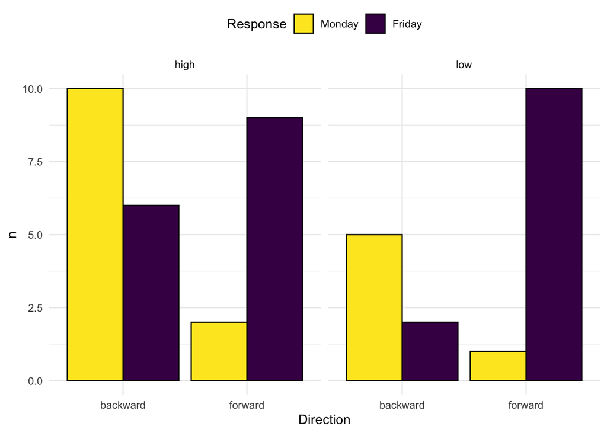

```r
E2 %>%
  count(Direction, AQ_cat, Response) %>%
  filter(!is.na(AQ_cat)) %>%
  ggplot(aes(x = Direction, y = n, fill = Response)) +
  geom_bar(stat = 'identity', col = 'black',
           position = 'dodge') +
  scale_fill_viridis_d(option = 'D', direction = -1) +
  theme_minimal() +
  theme(legend.position = 'top') +
  facet_wrap(~AQ_cat)
```

Visualize the main perspective-relevant result (direction) as a function of likeability of the person:

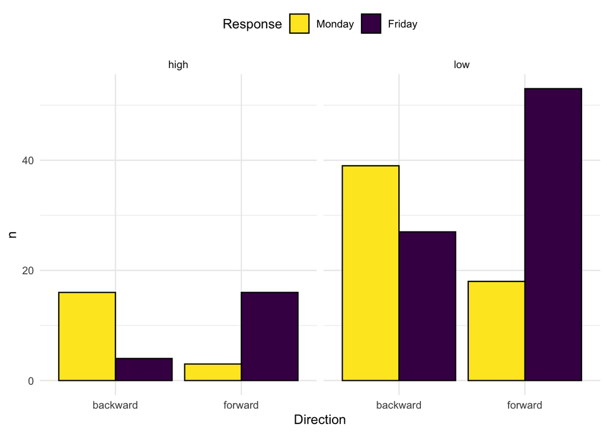

```r
E2 %>%
  count(Direction, Like_cat, Response) %>%
  filter(!is.na(Like_cat)) %>%
  ggplot(aes(x = Direction, y = n, fill = Response)) +
  geom_bar(stat = 'identity', col = 'black',
           position = 'dodge') +
  scale_fill_viridis_d(option = 'D', direction = -1) +
  theme_minimal() +
  theme(legend.position = 'top') +
  facet_wrap(~Like_cat)
```

## Model this with logistic regression:

Sum-code the categorical predictors:

```r
contrasts(E2$Direction) <- contr.sum(2) / 2 * -1
contrasts(E2$HandShape) <- contr.sum(2) / 2 * -1
contrasts(E2$HandNumber) <- contr.sum(2) / 2 * -1
```

Set the parameters for a Bayesian analysis:

```r
# For parallel processing:

options(mc.cores=parallel::detectCores())

# For handling the MCMC sampling:

my_controls <- list(adapt_delta = 0.99,
                    max_treedepth = 13)
```

Set regularizing priors on betas:

```r
my_priors <- c(prior(normal(0, 1), class = b))
```

Specify and run the model:

```r
E2_mdl <- brm(Response ~ Direction * HandShape * HandNumber,
              data = E2,
              family = bernoulli,
              init = 0,
              chains = 8,
              warmup = 2000,
              iter = 8000,
              prior = my_priors,
              control = my_controls)
save(E2_mdl, file = '../models/E2_mdl.RData')
```

Summarize the model:

```r
summary(E2_mdl)
```

```
##  Family: bernoulli
##   Links: mu = logit
## Formula: Response ~ Direction * HandShape * HandNumber
##    Data: E2 (Number of observations: 199)
## Samples: 8 chains, each with iter = 8000; warmup = 2000; thin = 1;
##          total post-warmup samples = 48000
##
## Population-Level Effects:
##                                   Estimate Est.Error l-95% CI u-95% CI
## Intercept                             0.33      0.16     0.01     0.65
## Direction1                            1.76      0.31     1.16     2.39
## HandShape1                            0.71      0.31     0.10     1.33
## HandNumber1                           0.08      0.31    -0.53     0.69
## Direction1:HandShape1                 0.09      0.55    -0.99     1.18
## Direction1:HandNumber1                0.75      0.55    -0.32     1.84
## HandShape1:HandNumber1               -0.39      0.55    -1.47     0.68
## Direction1:HandShape1:HandNumber1    -0.20      0.79    -1.75     1.37
##                                   Eff.Sample Rhat
## Intercept                              60344 1.00
## Direction1                             56689 1.00
## HandShape1                             61570 1.00
## HandNumber1                            59172 1.00
## Direction1:HandShape1                  55745 1.00
## Direction1:HandNumber1                 62589 1.00
## HandShape1:HandNumber1                 60165 1.00
## Direction1:HandShape1:HandNumber1      61598 1.00
##
## Samples were drawn using sampling(NUTS). For each parameter, Eff.Sample
## is a crude measure of effective sample size, and Rhat is the potential
## scale reduction factor on split chains (at convergence, Rhat = 1).
```

Plot marginal effects:

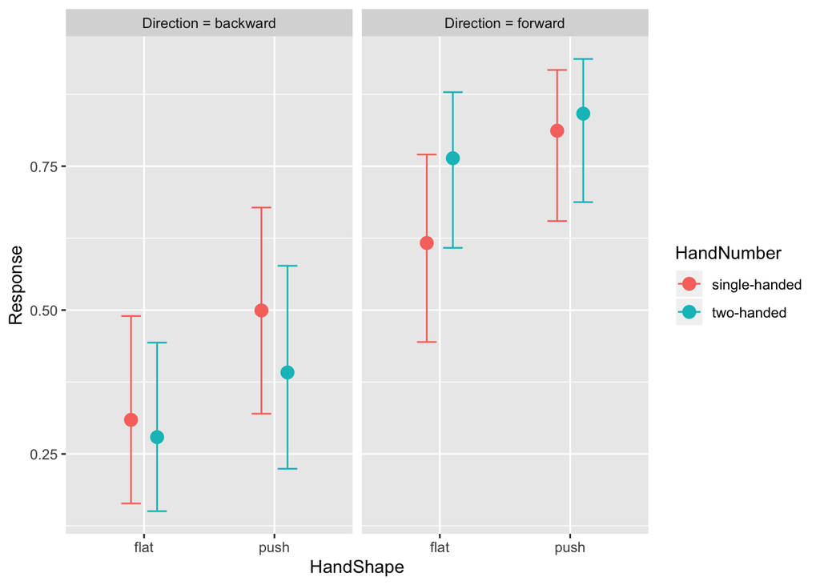

```r
conditions <- make_conditions(E2_mdl, 'Direction')
marginal_effects(E2_mdl, effects = 'HandShape:HandNumber',
                 conditions = conditions)
```

Check how many of the posteriors were in the predicted direction:

```r
# To aid interpretation:

levels(E2$Response)
```

```
## [1] "Monday" "Friday"
```

```r
contrasts(E2$Direction)
```

```
##          [,1]
## backward -0.5
## forward   0.5
```

```r
# Extract posterior samples:

mypost <- posterior_samples(E2_mdl)

# Posterior probability of the language effect being above 0:

sum(mypost$b_Direction1 > 0) / nrow(mypost)
```

```
## [1] 1
```

```r
# Same for the hand shape effect:

sum(mypost$b_HandShape1 > 0) / nrow(mypost)
```

```
## [1] 0.9887708
```

```r
# Same for the hand shape effect:

sum(mypost$b_HandNumber1 > 0) / nrow(mypost)
```

```
## [1] 0.5994167
```

## Check influence of AQ / likeability on direction:

Model with likeability/AQ * direction interaction.

```r
E2_social_mdl <- brm(Response ~ Direction * (AQ + LikeScale_c),
              data = E2,
              family = bernoulli,
              init = 0,
              chains = 8,
              warmup = 2000,
              iter = 8000,
              prior = my_priors,
              control = my_controls)
```

```
## recompiling to avoid crashing R session
```

```r
save(E2_social_mdl, file = '../models/E2_social_mdl.RData')
```

Check:

```r
summary(E2_social_mdl)
```

```
##  Family: bernoulli
##   Links: mu = logit
## Formula: Response ~ Direction * (AQ + LikeScale_c)
##    Data: E2 (Number of observations: 198)
## Samples: 8 chains, each with iter = 8000; warmup = 2000; thin = 1;
##          total post-warmup samples = 48000
##
## Population-Level Effects:
##                        Estimate Est.Error l-95% CI u-95% CI Eff.Sample
## Intercept                  0.98      1.24    -1.43     3.45      40785
## Direction1                 0.79      0.92    -1.00     2.59      24885
## AQ                        -0.13      0.24    -0.61     0.34      40971
## LikeScale_c               -0.01      0.07    -0.15     0.14      41225
## Direction1:AQ              0.20      0.19    -0.16     0.57      25082
## Direction1:LikeScale_c     0.24      0.14    -0.03     0.53      40621
##                        Rhat
## Intercept              1.00
## Direction1             1.00
## AQ                     1.00
## LikeScale_c            1.00
## Direction1:AQ          1.00
## Direction1:LikeScale_c 1.00
##
## Samples were drawn using sampling(NUTS). For each parameter, Eff.Sample
## is a crude measure of effective sample size, and Rhat is the potential
## scale reduction factor on split chains (at convergence, Rhat = 1).
```

Plot the LikeScale effect:

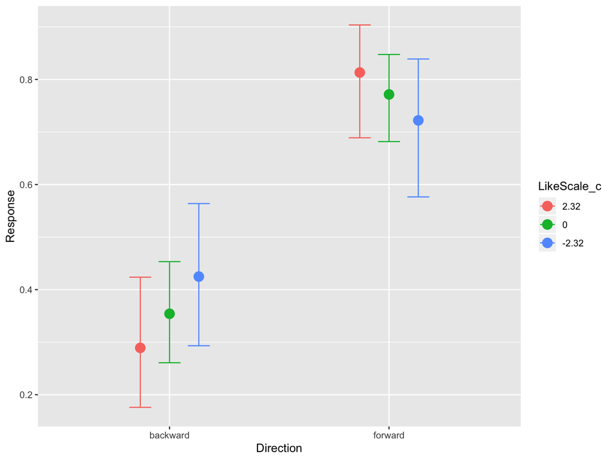

```r
marginal_effects(E2_social_mdl, effects = 'Direction:LikeScale_c')
```

Save the results outside for subsequent meta-analysis:

```r
write_csv(E2, '../data/cleaned_data/E2_cleaned.csv')
```

## Planning for other experiments

Find the hand shape for which the effect is strongest:

```r
# Flat hand shape:

E2_tab <- with(filter(E2, HandShape == 'flat'), table(Direction, Response))
E2_tab
```

```
##           Response
## Direction  Monday Friday
##   backward     37     14
##   forward      17     39
```

```r
chisq.test(E2_tab)$statistic
```

```
## X-squared
##  17.35737
```

```r
chisq.test(E2_tab)$stdres
```

```
##           Response
## Direction     Monday    Friday
##   backward  4.359784 -4.359784
##   forward  -4.359784  4.359784
```

```r
# Push hand shape:

E2_tab <- with(filter(E2, HandShape == 'push'), table(Direction, Response))
E2_tab
```

```
##           Response
## Direction  Monday Friday
##   backward     26     20
##   forward       7     39
```

```r
chisq.test(E2_tab)$statistic
```

```
## X-squared
##  15.30971
```

```r
chisq.test(E2_tab)$stdres
```

```
##           Response
## Direction     Monday    Friday
##   backward  4.130138 -4.130138
##   forward  -4.130138  4.130138
```

Push and flat about equal.

This completes this analysis.